# Lasting effects of PM2.5 in the 2007 Southern Californian Wildfires

By Baili Zhong, Pomona College EA30, Environmental Analysis

Oct 13, 2018

California has one of the highest rates of wildfires and as such, one of the highest rates of fire risk. As more and more people encroach onto former wildlands, the health risk from the frequency and severity of wildfires will continue to grow. Wildfire smoke causes huge devastation from property damage to loss of life. They release a range of pollutants with adverse health effects. PM2.5 exposure is especially significant (Strand et al. 2012). PM2.5 is atmospheric particulate matter (PM) with a diameter of less than 2.5 micrometers, about 3% of the diameter of human hair (Miettinen 2018). The health risk caused by exposure to PM2.5 increases with more exposure time.

**According to the The American Heart Association:**

“Exposure to PM <2.5 um in diameter (PM2.5) over a few hours to weeks can trigger cardiovascular disease-related mortality and nonfatal events; longer-term exposure (eg, a few years) increases the risk for cardiovascular mortality to an even greater extent than exposures over a few days and reduces life expectancy within more highly exposed segments of the population by several months to a few years.” (Miettinen 2018)

###### *PM2.5 measures pollutants of a certain size by the mass per cubic meter of air: μg/m<sup>3</sup>.

**24-Hour PM2.5 Standard (μg/m<sup>3</sup>)**

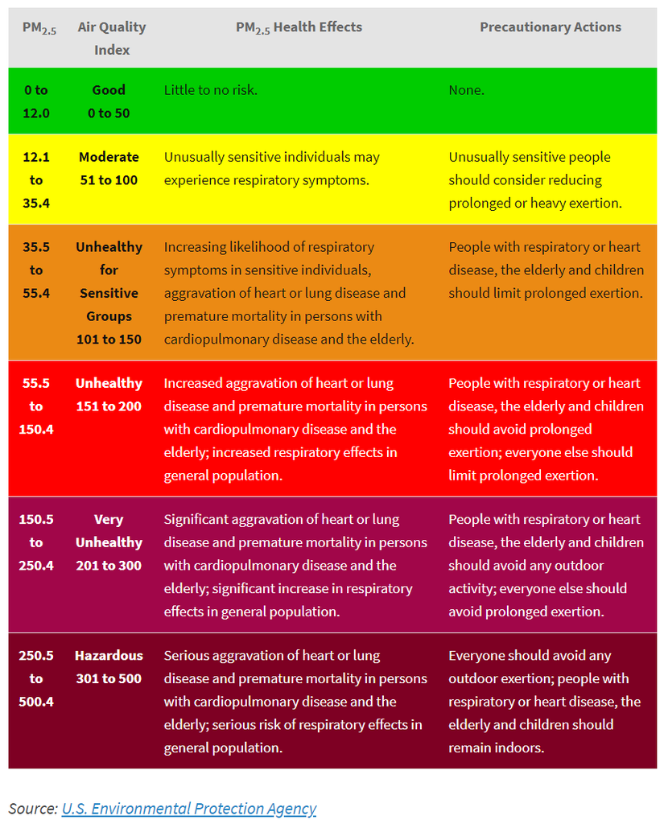

(Miettinen 2018).

**2007 Southern Californian Wildfires**

The Witch Fire was the second largest wildfire in the 2007 California wildfire season, claiming over 247,000 acres and 1,265 residential buildings (Wikipedia 2018). It lasted from October 21, 2007 to November 13, 2007. It started in Witch Creek Canyon, near Santa Ysabel and spread throughout San Diego County (Wikipedia 2018). The Harris, Witch, McCoy Fire, Coronado Hills Fire, Rice, Poomacha, Ammo (Horno) Fire, and Wilcox Fire also burned in San Diego County during this wildfire period. (Wikipedia 2018).

To study the effects of PM2.5 in the Witch Fire and surrounding fires, I looked at daily summaries from the “AQS Data Mart which contains ambient air pollution data collected by EPA, state, local, and tribal air pollution control agencies.” The data originally consisted of 5 monitoring stations in San Diego County (EPA 2008). Stations are named by the city where they are located and/or by the EPA’s station number. Street names were also provided for the two monitoring stations in the city of San Diego.The pre-fire period was from October 15, 2007 to October 20, 2007. October 21, 2007 to November 13, 2007 was the wildfire period. November 14, 2007 to December 31, 2007 was set as the post-fire period. The 12μg/m<sup>3</sup> primary annual standard and 35.4μg/m<sup>3</sup> safety threshold were used primarily to extrapolate health effects with the understanding that longer exposure to PM2.5 could decrease the PM2.5 levels necessary to cause negative health effects.

[figure not shown]

**Context:** Strong Santa Ana winds pushed the fires west toward the coast forcing over 500,000 people to evacuate. On Monday, October 22, the Santa Ana winds peaked with sustained wind speeds of 90mph (140km/h).

**Analysis: How does proximity to wildfire affect PM2.5 exposure and health risk?**

[figure not shown]

Peak Days of PM2.5 for the 2007 Southern California Wildfires

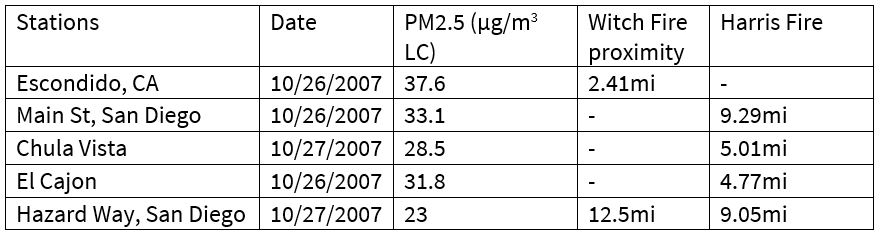

PM2.5 on Oct 26/07 *Miles not shown reflect >13mi distance from fire

[figure not shown]

Map of 2007 California wildfires as of Oct 26, 2007. The Harris, Witch, Rice, Poomacha, Horno, Wilcox, and Rosa Fires are also included. (Ranger Al 2007). Monitoring stations added by Baili Zhong in blue. Map Link: https://www.google.com/maps/d/u/0/viewer?mid=1iamjtnoH46clRmWGmxgovE_mn_TLmMRE&ll=32.772992998925375%2C-117.0564055829168&z=11

###### *Stations are referred to by location and proximity to wildfire as of Oct 26 according to the above map.

**Limitations:** The EPA data set used in this study only measured PM2.5 and did not include other harmful pollutants such as CO, Pb, NO<sub>2</sub>, Ozone, PM10, and SO<sub>2</sub>. Furthermore, the data did not extend further than the 2007 year and thus, PM2.5 concentrations may fluctuate longer than the observed period after a major wildfire, increasing health risk. Wind conditions besides the Santa Ann were not mentioned and could explain the discrepancy between Hazard Way, San Diego and Main St, San Diego PM2.5 levels despite their <0.3mi difference from the wildfire perimeters. Furthermore, the Map of 2007 California wildfires presented only showed the fire perimeters as of Oct 26, 2007. Thus, the effect of wildfire proximity on PM2.5 levels could be further explored with more daily analyses of fire perimeter to monitoring station distance.

**LITERATURE CITED**

Kochi, Ikuho. et al. 2016. “Valuing Morbidity Effects of Wildfire Smoke Exposure from the 2007 Southern California Wildfires.” Journal of Forest Economics, vol. 25, 2016, pp. 29–54, doi:10.1016/j.jfe.2016.07.002

Miettinen, Ville. 2018. “What is PM2.5 and Why You Should Care.” https://blissair.com/what-is-pm-2-5.htm

Ranger Al. 2007. “Witch Fire Map Oct 26/07.” http://www.fireupdate.com/2007/2007maps.htm.

Strand, T. et al. 2012. “Analyses of Bluesky Gateway PM2.5 Predictions during the 2007 Southern and 2008 Northern California Fires.” Journal of Geophysical Research D: Atmospheres, vol. 117, pp. 1-14, doi:10.1029/2012JD017627

United States Environmental Protection Agency (EPA). 2008. “Outdoor Air Quality Data.” https://www.epa.gov/outdoor-air-quality-data/download-daily-data

United States Environmental Protection Agency (EPA). 2012. “REVISED AIR QUALITY STANDARDS FOR PARTICLE POLLUTION AND UPDATES TO THE AIR QUALITY INDEX (AQI).” https://www.epa.gov/sites/production/files/201604/documents/2012_aqi_factsheet.pdf

Wikipedia contributors. 2018. “2007 California wildfires.” 2018. https://en.wikipedia.org/wiki/2007_California_wildfires

Wikipedia contributors. 2018. “Witch Fire.” 2018. https://en.wikipedia.org/wiki/Witch_Fire